## Impacts of Severe Weather Events on US Population Health and Economy

Jerry Peng, 6-1-2014

### 1- Synopsis

The Impacts of severe weather events on US population health and economy have been studied based on the data published by U.S. National Oceanic and Atmospheric Administration’s (NOAA) storm database, which tracks characteristics of major storms and weather events in the United States, from 1950 to November 2011. Our analysis concludes that the tornado is the most harmful to population heath, and the flood has the greatest economic impacts on economics.

### 2- Data Processing

The severe weather dataset from the U.S. National Oceanic and Atmospheric Administration’s (NOAA) storm database is loaded :

```r
if(!(exists("raw_data"))){
  raw_data <- read.csv("repdata_data_StormData.csv")
}
```

This database tracks characteristics of major storms and weather events in the United States, including when and where they occur, as well as estimates of any fatalities, injuries, and property damage.

We keep only the relevent features for this study, which are: * EVTYPE: event type * FATALITIES * INJURIES * PROPDMG: property damage * PROPDMGEXP: unit of property damage * CROPDMG: crop damage * CROPDMGEXP: unit of crop damage

```r
new_data <- raw_data[,c("EVTYPE","FATALITIES","INJURIES","PROPDMG","PROPDMGEXP","CROPDMG","CROPDMGEXP")]
```

The total number of of the event types is 985. We need to classify them into groups. According to National Weather Service Storm Data Documentation (https://d396qusza40orc.cloudfront.net/repdata%2Fpeer2_doc%2Fpd01016005curr.pdf), there are 48 events as listed below:

```
##  [1] "astronomical low tide"    "avalanche"
##  [3] "blizzard"                 "coastal flood"
##  [5] "cold/wind chill"          "debris flow"
##  [7] "dense fog"                "dense smoke"
##  [9] "drought"                  "dust devil"
## [11] "dust storm"               "excessive heat"
## [13] "extreme cold/wind chill"  "flash flood"
## [15] "flood"                    "frost/freeze"
## [17] "funnel cloud"             "freezing fog"
## [19] "hail"                     "heat"
## [21] "heavy rain"               "heavy snow"
## [23] "high surf"                "high wind"
## [25] "hurricane (typhoon)"      "ice storm"
## [27] "lake-effect snow"         "lakeshore flood"
## [29] "lightning"                "marine hail"
## [31] "marine high wind"         "marine strong wind"
## [33] "marine thunderstorm wind" "rip current"
## [35] "seiche"                   "sleet"
## [37] "storm surge/tide"         "strong wind"
## [39] "thunderstorm wind"        "tornado"
## [41] "tropical depression"      "tropical storm"
## [43] "tsunami"                  "volcanic ash"
## [45] "waterspout"               "wildfire"
## [47] "winter storm"             "winter weather"
```

We need clean up the data of event types, and divide them into the 48 groups as listed above. First we convert all type names to lower case, and remove the spaces and “&”,“/”,“-” and numbers in the names using regular expression:

```r
new_data$EVTYPE=tolower(as.character(new_data$EVTYPE))
new_data$EVTYPE=gsub("\\s+|/|-|\\+|&|and|[0-9]+","",new_data$EVTYPE)
tmp<-as.character(levels(factor(new_data$EVTYPE)))
```

Next we calculate the distances between the names of event types in the dataset, and 48 the group names by calculating the “edit distance” between strings, and pick the minimum distance as its group:

```r
# calculate the "edit distance" using adist,and then pick the index corresponding to the minimum distance
distE<-sapply(tmp,function(x) which.min(mapply(adist,x,EVType)))
names(distE)<-tmp
new_data$New_EVTYPE<-factor(EVType[distE[new_data$EVTYPE]])
```

After this, all 985 types of events are reduced to 48 event types.

### 3. Results

#### Population Health

We first analyse the severe weather effect on population health. We calculate the sum of the numbers of injuries and fatalities caused by severe weather,

```r
library(plyr)
```

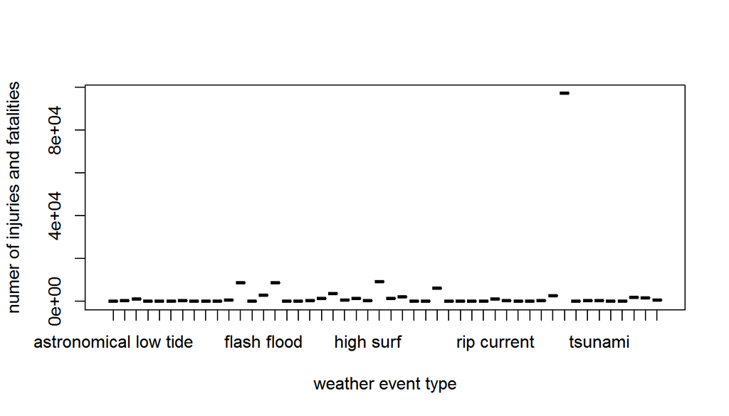

```r
Health_Data<-ddply(new_data,"New_EVTYPE", function(df) sum(df$FATALITIES+df$INJURIES))
names(Health_Data)=c("New_EVTYPE","Death_Injury")
plot(Health_Data$New_EVTYPE,Health_Data$Death_Injury,xlab="weather event type",
     ylab="numer of injuries and fatalities")
```

from the above plot, it is clear that the number of injuries and fatalities caused by tornado is significantly higher than other events.

```r
Health_Data$New_EVTYPE[which.max(Health_Data$Death_Injury)]
```

```
## [1] tornado
## 48 Levels: astronomical low tide avalanche blizzard ... winter weather
```

#### Economy

```r
levels(new_data$PROPDMGEXP)
```

```
##  [1] ""  "-" "?" "+" "0" "1" "2" "3" "4" "5" "6" "7" "8" "B" "h" "H" "K"
## [18] "m" "M"
```

```r
new_data$N_PROPDMGEXP<-0
new_data$N_PROPDMGEXP[tolower(as.character(new_data$PROPDMGEXP)) %in% c("","-","?","+")]<-0
new_data$N_PROPDMGEXP[tolower(as.character(new_data$PROPDMGEXP)) =="h"]<-2
new_data$N_PROPDMGEXP[tolower(as.character(new_data$PROPDMGEXP)) =="k"]<-3
new_data$N_PROPDMGEXP[tolower(as.character(new_data$PROPDMGEXP)) =="m"]<-6
new_data$N_PROPDMGEXP[tolower(as.character(new_data$PROPDMGEXP)) =="b"]<-9
```

```r
new_data$N_CROPMGEXP<-0
new_data$N_CROPDMGEXP[tolower(as.character(new_data$CROPDMGEXP)) %in% c("","?")]<-0
new_data$N_CROPDMGEXP[tolower(as.character(new_data$CROPDMGEXP)) =="k"]<-3
new_data$N_CROPDMGEXP[tolower(as.character(new_data$CROPDMGEXP)) =="m"]<-6
new_data$N_CROPDMGEXP[tolower(as.character(new_data$CROPDMGEXP)) =="b"]<-9
```

After that, we can calculate the property/crop damages as follows:

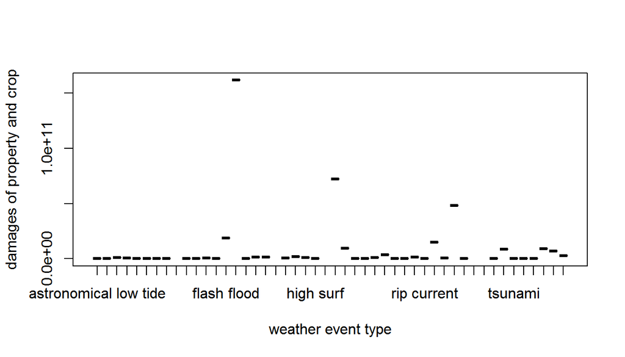

```r
ECO_Data<-ddply(new_data,"New_EVTYPE", function(df) sum(df$PROPDMG*10^df$N_PROPDMGEXP+
                                                      df$CROPDMG*10^df$N_CROPDMGEXP))
names(ECO_Data)=c("New_EVTYPE","PropDamage_CROPDamage")
plot(ECO_Data$New_EVTYPE,ECO_Data$PropDamage_CROPDamage,xlab="weather event type",
     ylab="damages of property and crop")
```

it is clear from the above plot that the damages in property and crop caused by flood is significantly higher than other events.

```r
ECO_Data$New_EVTYPE[which.max(ECO_Data$PropDamage_CROPDamage)]
```

```
## [1] flood
## 48 Levels: astronomical low tide avalanche blizzard ... winter weather
```

### 4. Conclusion

we conclude :

- The most harmful weather event for population health is tornado
- The most harmful weather event for economy is flood